# lab1_Chen

Weixuan Chen

1/25/2023

## Task 1

```r
d1=read.csv("http://faraway.neu.edu/biostats/lab1_dataset1.csv")
d1
```

```
##        sex treatment  outcome
## 1     male   placebo     sick
## 2     male   placebo     sick
## 3     male   placebo     sick
## 4     male   placebo not sick
## 5     male   placebo     sick
## 6     male   placebo     sick
## 7     male   placebo not sick
## 8     male   placebo     sick
## 9     male   placebo     sick
## 10    male   placebo     sick
## 11    male   placebo     sick
## 12    male   placebo     sick
## 13    male   placebo     sick
## 14    male   placebo     sick
```

[output cut: 146 more lines]

## 1

```r
str(d1)
```

```
## 'data.frame':    160 obs. of  3 variables:
##  $ sex      : Factor w/ 2 levels "female","male": 2 2 2 2 2 2 2 2 2 2 ...
##  $ treatment: Factor w/ 2 levels "drug","placebo": 2 2 2 2 2 2 2 2 2 2 ...
##  $ outcome  : Factor w/ 2 levels "not sick","sick": 2 2 2 1 2 2 1 2 2 2 ...
```

The variables are “sex”, “treatment”, “outcome” respectively. The data type is categorical.

## 2a

```r
table(subset(d1, select = c("sex","outcome")))
```

```
##         outcome
## sex      not sick sick
##   female       71    9
##   male         31   49
```

It seems the disease is more prevalent in male group than female group.

# 2b

```r
table(subset(d1, select = c("treatment","outcome")))
```

```
##          outcome
## treatment not sick sick
##   drug          63   17
##   placebo       39   41
```

Drugs seems to be more effective because the proportion of “not sick” is obviously greater than that of placebo.

The effectiveness is contigent to te sex subject because the male and female groups have the same number of people having these two medicine but the effectiveness of female group outperforms that of male group.

## 3

```r
prop.female <- function(vec){
sum(vec == "female") / length(vec)
}
aggregate(sex ~ treatment, data = d1, FUN = prop.female)
```

```
##   treatment sex
## 1      drug 0.5
## 2   placebo 0.5
```

```r
prop.sick <- function(vec){
sum(vec == "sick") / length(vec)
}
aggregate(outcome ~ treatment, data = d1, FUN = prop.sick)
```

```
##   treatment outcome
## 1      drug  0.2125
## 2   placebo  0.5125
```

It is obvious that based on the whole group of sick people, the drug is more effetive. So I would suggest anyone who got the disease to take the drug.

## 4

According to the previous tables, we can observe that drug works better on females than males.

## Task 2

```r
d2=read.csv("http://faraway.neu.edu/biostats/lab1_dataset2.csv")
d2
```

```
##        sex treatment  outcome side.effects
## 1     male         1     sick          yes
## 2     male         1     sick           no
## 3     male         1     sick          yes
## 4     male         1 not sick           no
## 5     male         1     sick           no
## 6     male         1     sick           no
## 7     male         1 not sick           no
## 8     male         1     sick          yes
## 9     male         1     sick           no
## 10    male         1     sick           no
## 11    male         1     sick           no
## 12    male         1     sick           no
## 13    male         1     sick           no
## 14    male         1     sick          yes
```

[output cut: 786 more lines]

## 1

```r
str(d2)
```

```
## 'data.frame':    800 obs. of  4 variables:
##  $ sex         : Factor w/ 2 levels "female","male": 2 2 2 2 2 2 2 2 2 2 ...
##  $ treatment   : int  1 1 1 1 1 1 1 1 1 1 ...
##  $ outcome     : Factor w/ 2 levels "not sick","sick": 2 2 2 1 2 2 1 2 2 2 ...
##  $ side.effects: Factor w/ 2 levels "no","yes": 2 1 2 1 1 1 1 2 1 1 ...
```

The names of variables are “sex”, “treatment”, “outcome”, “side.effects” respectively. The data type of sex, outcome and side.effect is categorical and that of treatment is numerical(int).

## 2

```r
prop.sick <- function(vec){
sum(vec == "sick") / length(vec)
}
my_agg <- aggregate(outcome ~ treatment, data = d2, FUN = prop.sick)
my_agg
```

```
##    treatment outcome
## 1          1  0.6250
## 2          2  0.4750
## 3          3  0.5375
## 4          4  0.5875
## 5          5  0.3500
## 6          6  0.2625
## 7          7  0.2125
## 8          8  0.1875
## 9          9  0.2625
## 10        10  0.2500
```

It seems that some medicine has smaller proportion of sick outcome than others. It can explain the effectiveness of the drug to some extent.

## 3

```r
sick.males=subset(d2, sex == "male") # Select males
sick.males
```

```
##      sex treatment  outcome side.effects
## 1   male         1     sick          yes
## 2   male         1     sick           no
## 3   male         1     sick          yes
## 4   male         1 not sick           no
## 5   male         1     sick           no
## 6   male         1     sick           no
## 7   male         1 not sick           no
## 8   male         1     sick          yes
## 9   male         1     sick           no
## 10  male         1     sick           no
## 11  male         1     sick           no
## 12  male         1     sick           no
## 13  male         1     sick           no
## 14  male         1     sick          yes
```

[output cut: 386 more lines]

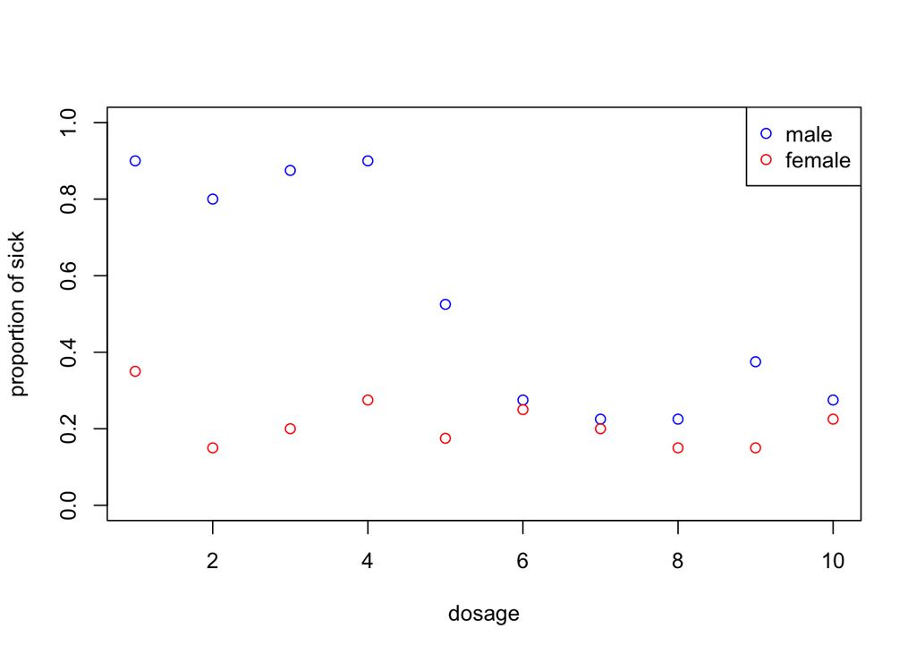

```r
sick.males=subset(d2, sex == "male") # Select males
sick.females=subset(d2, sex=="female") # Select females
sick.males=aggregate(outcome ~ treatment, data = sick.males, FUN = prop.sick)
sick.females=aggregate(outcome ~ treatment, data = sick.females, FUN = prop.sick)
plot (sick.males$treatment, sick.males$outcome, ylim=c(0, 1),
col='blue', xlab="dosage", ylab="proportion of sick")
points (sick.females$treatment, sick.females$outcome, ylim=c(0, 1), col='red')
legend(x="topright", legend=c("male", "female"), col=c("blue", "red"), pch=1)
```

The disease prevalence is high for drug 1 to 5 and low for drug 6 to 10 in male group. The disease prevalence is quite low in all drugs for female group. I would describe the change is non-linear. The drug 1 to 4 seem to have disproportion for male and female groups which suggests that their effectiveness may differ based on sex. I would suggest drug 7 because it is both effective to males and females and it has relatively low proportion of sickness.

## Task 3

## 1

```r
prop.side <- function(vec){
sum(vec == "yes") / length(vec)
}
my_side <- aggregate(side.effects ~ sex + treatment, data = d2, FUN = prop.side)
my_side
```

```
##       sex treatment side.effects
## 1  female         1        0.200
## 2    male         1        0.300
## 3  female         2        0.450
## 4    male         2        0.275
## 5  female         3        0.300
## 6    male         3        0.325
## 7  female         4        0.350
## 8    male         4        0.475
## 9  female         5        0.500
## 10   male         5        0.350
## 11 female         6        0.400
## 12   male         6        0.550
## 13 female         7        0.600
## 14   male         7        0.700
## 15 female         8        0.700
## 16   male         8        0.750
## 17 female         9        0.725
## 18   male         9        0.775
## 19 female        10        0.925
## 20   male        10        0.875
```

The proportion of side effect increases from drug 1 to drug 10 in both group of sex.

## 2

```r
prop.sick <- function(vec){
sum(vec == "sick") / length(vec)
}
my_sick <- aggregate(outcome ~ sex + treatment, data = d2, FUN = prop.sick)
my_sick
```

```
##       sex treatment outcome
## 1  female         1   0.350
## 2    male         1   0.900
## 3  female         2   0.150
## 4    male         2   0.800
## 5  female         3   0.200
## 6    male         3   0.875
## 7  female         4   0.275
## 8    male         4   0.900
## 9  female         5   0.175
## 10   male         5   0.525
## 11 female         6   0.250
## 12   male         6   0.275
## 13 female         7   0.200
## 14   male         7   0.225
## 15 female         8   0.150
## 16   male         8   0.225
## 17 female         9   0.150
## 18   male         9   0.375
## 19 female        10   0.225
## 20   male        10   0.275
```

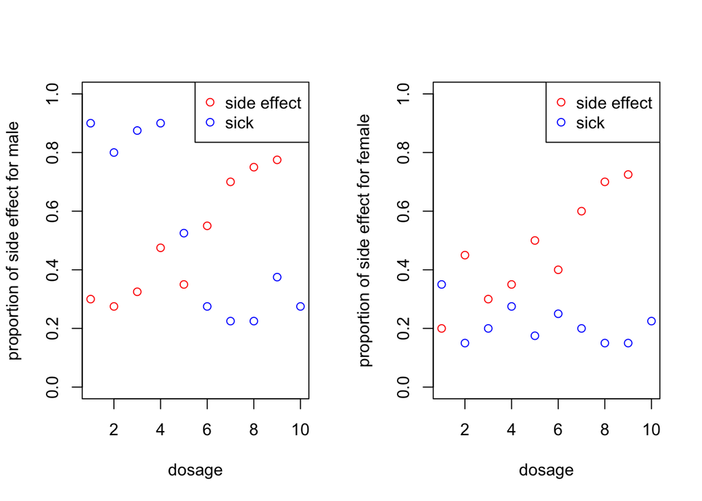

```r
my_side.male <- subset(my_side, sex == "male")
my_side.female <- subset(my_side, sex == "female")

my_sick.male <- subset(my_sick, sex == "male")
my_sick.female <- subset(my_sick, sex == "female")

par(mfrow=c(1,2))
plot (my_side.male$treatment, my_side.male$side.effects, ylim=c(0, 1),
col='red', xlab="dosage", ylab="proportion of side effect for male")
points (my_sick.male$treatment, my_sick.male$outcome, ylim=c(0, 1), col='blue')
legend(x="topright", legend=c("side effect", "sick"), col=c("red", "blue"), pch=1)

plot (my_side.female$treatment, my_side.female$side.effects, ylim=c(0, 1),
col='red', xlab="dosage", ylab="proportion of side effect for female")
points (my_sick.female$treatment, my_sick.female$outcome, ylim=c(0, 1), col='blue')
legend(x="topright", legend=c("side effect", "sick"), col=c("red", "blue"), pch=1)
```

## 3

I would suggest drug 6 for male because it has a low rate of sickness and comparatively medium side effect. I would suggest drug 3 for female for the same reason. Overall, I would suggest drug 6 because it has the best average performance among two groups. It contradicts with my previous recommendation.